# Vanishing and Exploding Gradients

In the realm of deep learning, the optimization process plays a crucial role in training neural networks. **Gradient descent**, a fundamental optimization algorithm, plays a central role in training a neural network as it indicates the direction and magnitude of weight updates during backpropagation. However, it can sometimes encounter two major issues:

1. Vanishing Gradients
2. Exploding Gradients

1. Overview

### 1.1 Backpropagation - A glimpse

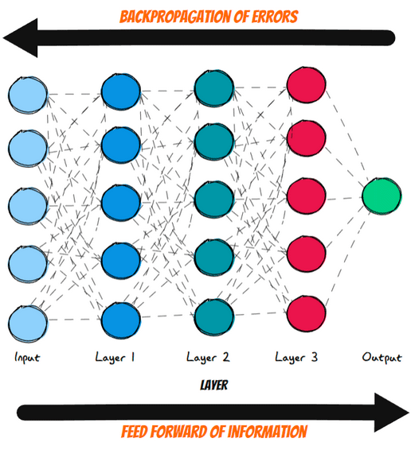

Backpropagation is used to reduce the difference between the model’s predicted output and the actual output by adjusting the weights and biases iteratively to minimize the cost function in the network. In each epoch, the model adapts these parameters by reducing loss by following the error gradient. It often uses optimization algorithms like gradient descent or stochastic gradient descent. It computes the gradient using the chain rule from calculus, allowing it to effectively navigate complex layers in the neural network.

Generally speaking, training neural networks with backpropagation entails the following steps:

1. A *forward propagation or forward pass,* making predictions on training data.
2. A *loss function* measures the error of the model’s predictions during that forward pass.
3. *Backpropagation* of error, or a *backward pass, is used* to calculate the partial derivatives of the loss function.
4. *Gradient descent,* to update model weights.

Backpropagation involves computing the partial derivatives of the loss function with respect to each weight in the network, representing their contribution to the overall loss:

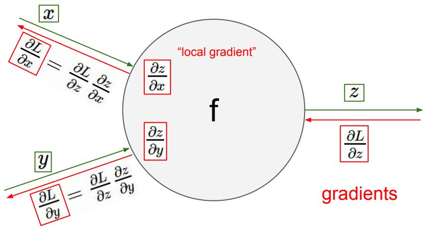

### 1.2 The unstable gradient problem

It is during the calculation of these derivatives that the gradient starts behaving ‘weirdly’ at some range of points. The vanishing gradient problem occurs when these gradients become extremely small as they propagate backward through multiple layers. Conversely, the exploding gradient problem happens when gradients grow exponentially during backpropagation.

## 2. How do they occur?

### 2.1 Vanishing Gradient

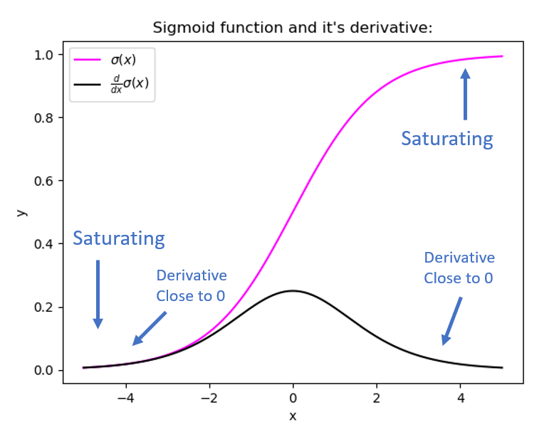

The **vanishing gradient problem** arises when gradients become extremely small as they are propagated backward through the layers of a deep neural network during training. This happens due to the repeated application of the chain rule in backpropagation, which involves multiplying several derivatives together. When activation functions like **sigmoid** or **tanh** are used, their derivatives are bounded and significantly less than 1 for most input values, especially in the saturated regions where inputs are either very positive or very negative. For example, the derivative of the sigmoid function never exceeds 0.25. As these small values are multiplied across many layers, the gradients shrink exponentially, often approaching zero in the earlier layers.

**Consequence:** This causes the weights in those layers to receive negligible updates, severely limiting their ability to learn. As a result, the network may converge very slowly, learn suboptimal representations, or fail to train effectively at all. This issue is especially prevalent in deep networks using **saturating activation functions**, where small gradients are an inherent mathematical consequence of their shape.

### 2.2 Exploding Gradient

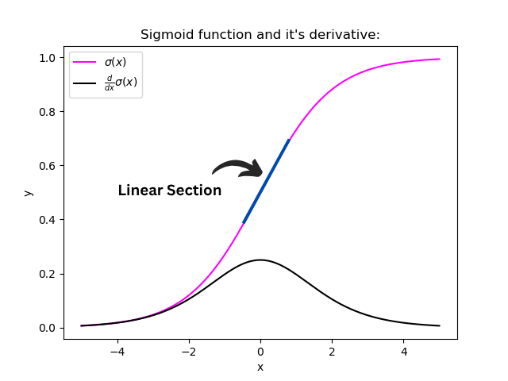

The exploding gradient problem occurs when the gradients of the loss function with respect to the weights (or parameters) become excessively large during backpropagation. This leads to gradients with magnitudes that grow exponentially, making training unstable and potentially causing numerical issues. Unlike vanishing gradient, where the root cause was the choice of activation function, exploding gradient can occur due to various factors like large weight initialization, the choice of activation function, network architecture, and the learning rate.

**Consequence:** When gradients explode, the weight updates during training can become so large that they cause the learning algorithm to overshoot the minima of the loss function. This can result in model parameters diverging to infinity, causing the learning process to fail. The model may exhibit erratic behavior, with the loss becoming NaN (not a number) or Inf (infinity), and the model's predictions becoming meaningless.

## 3. How to identify?

### 3.1 Detecting Vanishing Gradient Issue

The following are some indicators of a model suffering from the vanishing gradient problem:

1. Model weights are converging to 0, or there is stagnation in the model’s performance over training epochs.
2. If the loss function fails to decrease significantly, or if there is erratic behaviour in the learning curves.
3. Additionally, it is recommended to examine the behaviour of gradients during backpropagation. One can use different visualization techniques for this purpose.

### 3.2 Detecting Exploding Gradient Issue

Here are some of the ways to identify the exploding gradient problem:

1. The training process encounters ‘NaN’ values in the loss function or intermediate calculations.
2. If the network weights, during training, exhibit a significant or rapid increase in their values.
3. The loss function exhibits erratic behaviour, oscillating wildly instead of steadily decreasing, suggesting that the network weights are being updated excessively by large gradients.